# Proyecto Reglas Asociación

Juan Alcaraz Otón, Óscar Camacho Barreda

## Qualitative Bankruptcy Data Set

Utilizaremos UNA VERSIÓN PARECIDA PERO NO IGUAL del conjunto de datos `Qualitative_Bankruptcy Data Set` del repositorio *UCI Machine Learning* para trabajar el estudio de las variables Categóricas/Cualitativas y la bondad de las reglas de Asociación para extraer conocimiento de un conjunto de datos, en este caso, predecir la bancarrota (*Bankruptcy*) en base a parámetros cuantitativos/cualitativos preparados por expertos.

Cargar el fichero `Qualitative_Bankruptcy.num.txt` y crear el `data.frame` `QB`.

```r
#solucion

rm(list=ls())

library(arules)
library(readr)

QB <- read_csv("Qualitative_Bankruptcy.num.txt", col_names = FALSE)
```

Asigna nombres válidos a las columnas del `data.frame` (usa `make.names` para asegurarte que no contiene símbolos raros). Más información en el fichero `Qualitative_Bankruptcy.info.txt`

```r
colnames(QB) <- make.names(c("Industrial Risk", "Management Risk",
                               "Financial Flexibility","Credibility",
                               "Competitiveness", "Operating Risk",
                               "Bankruptcy"))
```

Sabiendo que las variables numéricas representan un valor entre 0 y 10 para indicar la valoración del experto de cada variable, prueba a discretizar las variables numéricas en 3 factores ordenados **QB** de *manera no supervisada* para estimar la clase (`Bankruptcy`). La etiqueta asociada a valores bajos será “N” de valoración “negative”, la etiqueta de valores altos será “P” de “positive” y el resto corresponderá a etiqueta “A” de “average”.

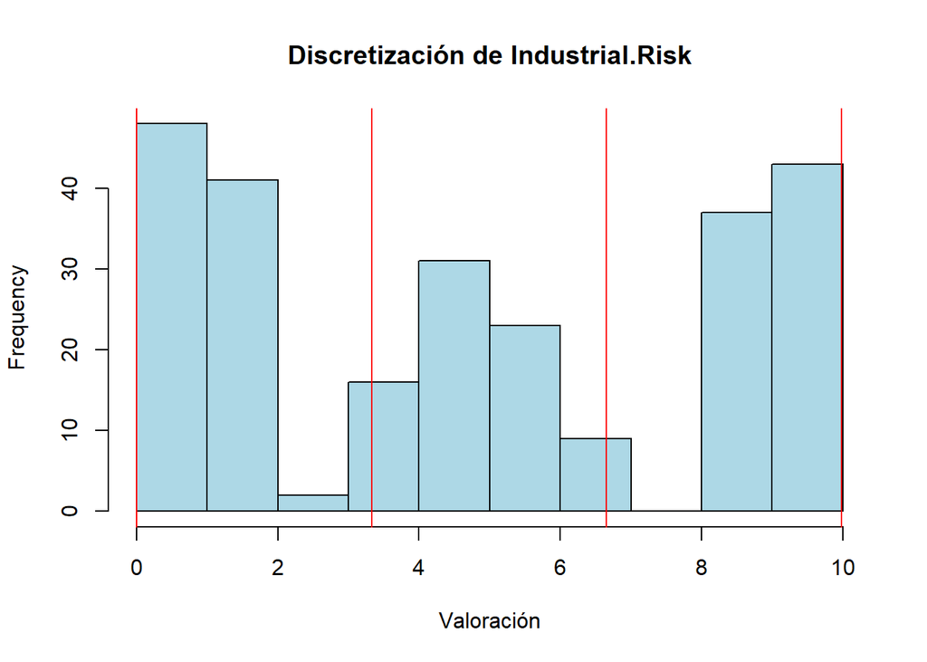

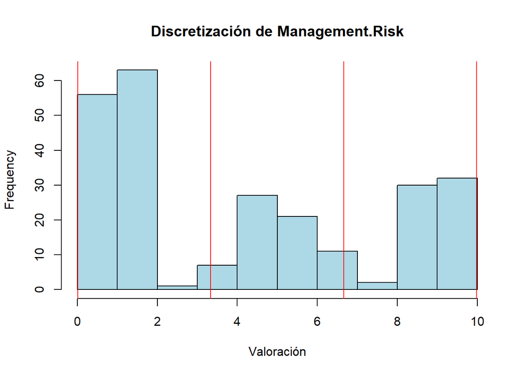

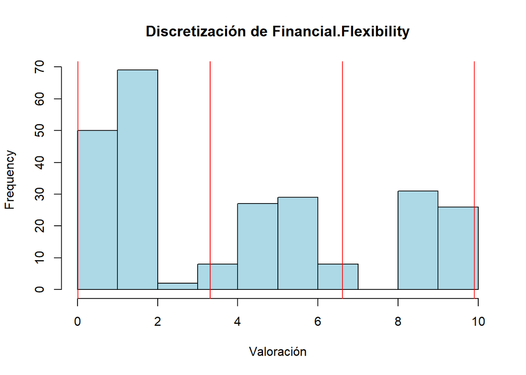

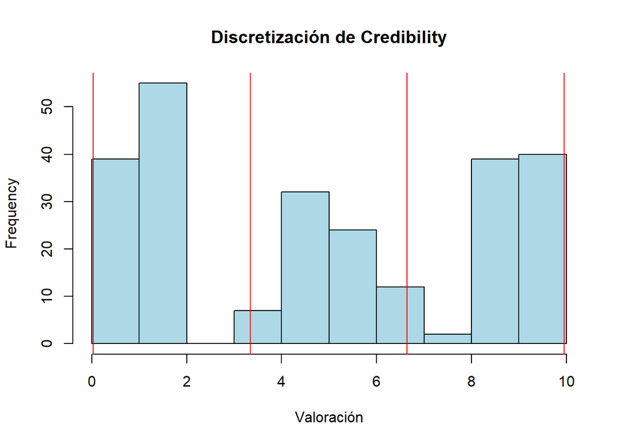

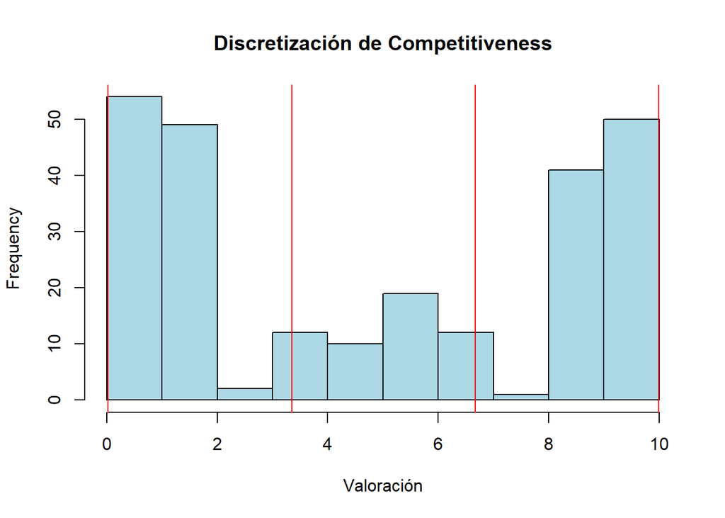

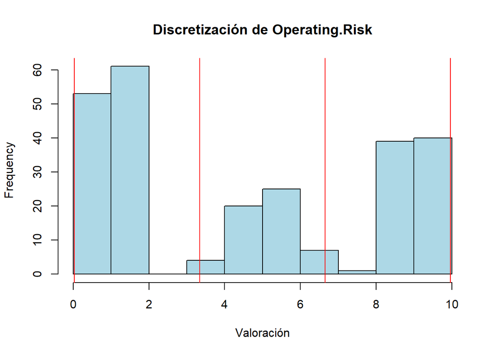

```r
#solucion

# Pasamos la columna de Bankruptcy a factor
QB$Bankruptcy <- as.factor(QB$Bankruptcy)

# Obtenemos los índices de columnas numéricas y sus nombres
cols_num <- sapply(QB,is.numeric)
nombres_num <- names(QB)[cols_num]

for(col_name in nombres_num){

  # Extraemos el vector numérico original de la columna
  vec_num <- QB[[col_name]]

  # Dibujamos el histograma
  hist(vec_num,
       breaks = 10,
       main = paste("Discretización de", col_name),
       xlab = "Valoración",
       col = "lightblue")

  # Calculamos los cortes entre los factores sobre el vector original
  cortes <- discretize(vec_num, method = "interval", breaks = 3, onlycuts = TRUE)

  # Dibujamos las líneas
  abline(v = cortes, col = "red")
}
```

```r
# Aplicamos la discretización a las columnas de una copia del df
QB_disc <- QB

QB_disc[, cols_num] <- lapply(QB[, cols_num], function(x) {
  # Asignamos las etiquetas en los intervalos correspondientes
  val_disc <- discretize(x, method = "interval", breaks = 3, labels = c("N", "A", "P"))

  # Garantizamos que son factores ordenados con N < A < P
  ordered(val_disc, levels = c("N", "A", "P"))
})
```

Asegúrate que toda las variables son factores de 3 niveles y ORDENADOS que respetan N<A<P. La clase `Bankruptcy` debe tener como primera etiqueta “B”.

```r
#solucion

# Verificamos que la estructura de "Bankruptcy" tenga "B" como primera etiqueta
QB_disc$Bankruptcy <- as.factor(QB_disc$Bankruptcy)
QB_disc$Bankruptcy <- relevel(QB_disc$Bankruptcy, ref = "B")

# Podemos ver que todas las variables numéricas aparecen como factores de 3 niveles ordenados (Ord.factor w/ 3 levels "N"<"A"<"P")
str(QB_disc)
```

```
## spc_tbl_ [250 × 7] (S3: spec_tbl_df/tbl_df/tbl/data.frame)
##  $ Industrial.Risk      : Ord.factor w/ 3 levels "N"<"A"<"P": 3 1 2 3 1 2 3 3 3 3 ...
##  $ Management.Risk      : Ord.factor w/ 3 levels "N"<"A"<"P": 3 1 2 3 1 2 3 3 3 3 ...
##  $ Financial.Flexibility: Ord.factor w/ 3 levels "N"<"A"<"P": 2 2 2 3 3 3 2 3 2 1 ...
##  $ Credibility          : Ord.factor w/ 3 levels "N"<"A"<"P": 2 2 2 3 3 3 3 2 3 2 ...
##  $ Competitiveness      : Ord.factor w/ 3 levels "N"<"A"<"P": 2 2 2 3 3 3 3 2 2 3 ...
##  $ Operating.Risk       : Ord.factor w/ 3 levels "N"<"A"<"P": 3 1 2 3 1 2 3 3 3 3 ...
##  $ Bankruptcy           : Factor w/ 2 levels "B","NB": 2 2 2 2 2 2 2 2 2 2 ...
##  - attr(*, "spec")=
##   .. cols(
##   ..   X1 = col_double(),
##   ..   X2 = col_double(),
##   ..   X3 = col_double(),
##   ..   X4 = col_double(),
##   ..   X5 = col_double(),
##   ..   X6 = col_double(),
##   ..   X7 = col_character()
##   .. )
##  - attr(*, "problems")=<externalptr>
```

## Análisis Cualitativo

Realiza un estudio del conjunto discretizado para determinar si es apropiado para resolver el problema (estimar Bankruptcy con el menor número de errores) .

### Análisis univariante de las variables Cualitativas

Obtén la descripción de las variables incluida la clase. Al menos, se debe obtener la tabla de frecuencias y un gráfico para mostrar la frecuencias.

```r
#solucion

# Resumimos las variables rápidamente para ver cómo se distribuyen los datos
summary(QB_disc)
```

```
##  Industrial.Risk Management.Risk Financial.Flexibility Credibility
##  N:94            N:121           N:123                 N:96
##  A:74            A: 65           A: 67                 A:69
##  P:82            P: 64           P: 60                 P:85
##  Competitiveness Operating.Risk Bankruptcy
##  N:108           N:114          B :107
##  A: 50           A: 53          NB:143
##  P: 92           P: 83
```

```r
# Tablas de frecuencias relativas y absolutas
for (nombre in names(QB_disc)) {
  cat("\n---", nombre, "---\n")
  frec_abs <- table(QB_disc[[nombre]])
  frec_rel <- prop.table(frec_abs)

  # Juntamos ambas en una matriz para que se lea mejor
  print(rbind(Absoluta = frec_abs, Relativa = round(frec_rel, 3)))
}
```

```
##
## --- Industrial.Risk ---
##               N      A      P
## Absoluta 94.000 74.000 82.000
## Relativa  0.376  0.296  0.328
##
## --- Management.Risk ---
##                N     A      P
## Absoluta 121.000 65.00 64.000
## Relativa   0.484  0.26  0.256
##
## --- Financial.Flexibility ---
##                N      A     P
## Absoluta 123.000 67.000 60.00
## Relativa   0.492  0.268  0.24
##
## --- Credibility ---
##               N      A     P
## Absoluta 96.000 69.000 85.00
## Relativa  0.384  0.276  0.34
##
## --- Competitiveness ---
##                N    A      P
## Absoluta 108.000 50.0 92.000
## Relativa   0.432  0.2  0.368
##
## --- Operating.Risk ---
##                N      A      P
## Absoluta 114.000 53.000 83.000
## Relativa   0.456  0.212  0.332
##
## --- Bankruptcy ---
##                B      NB
## Absoluta 107.000 143.000
## Relativa   0.428   0.572
```

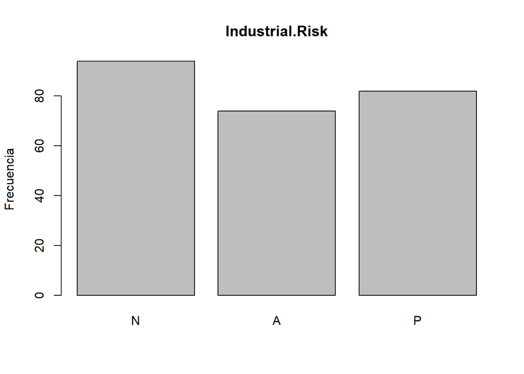

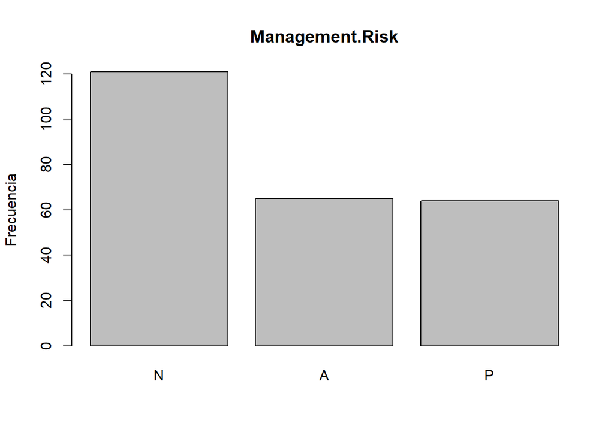

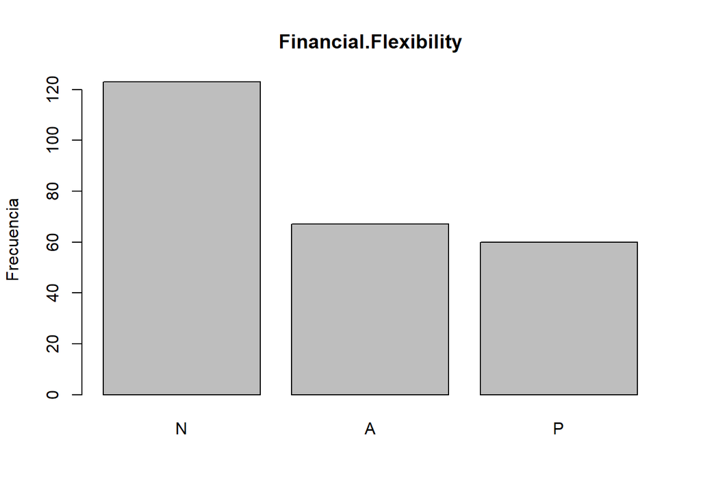

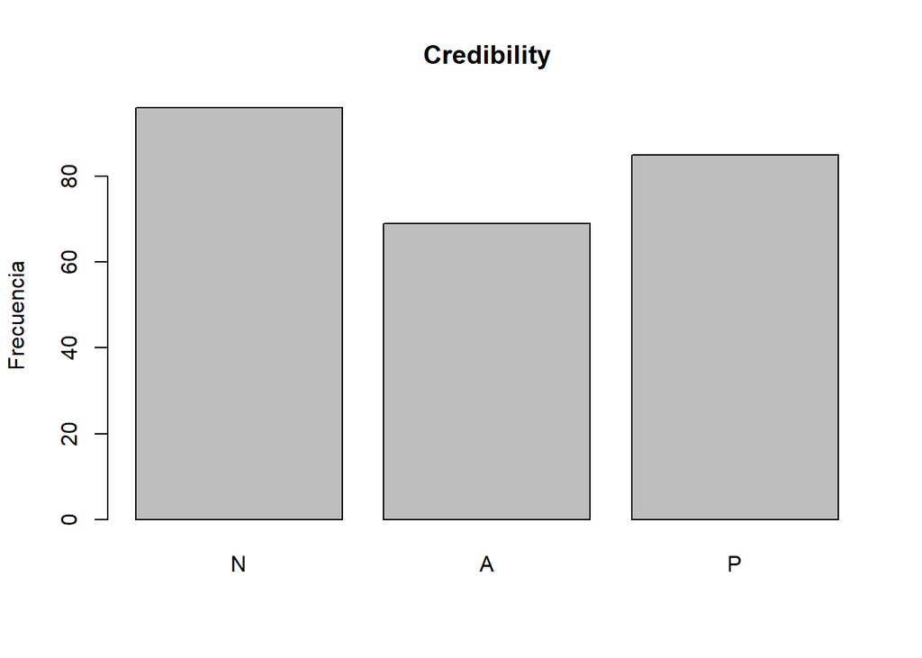

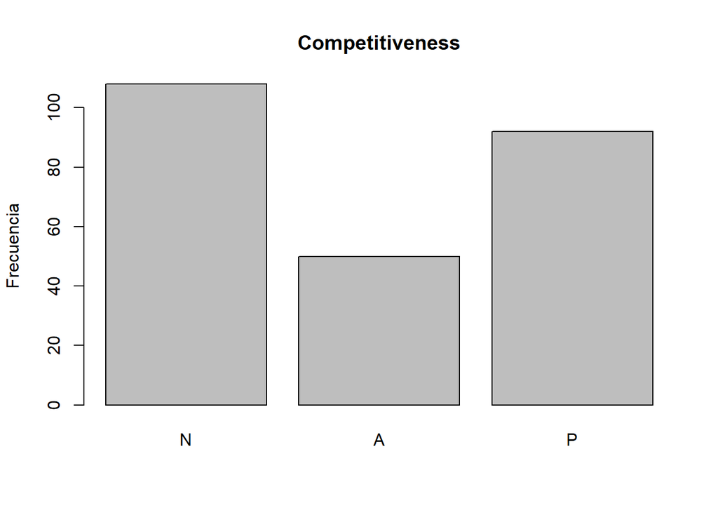

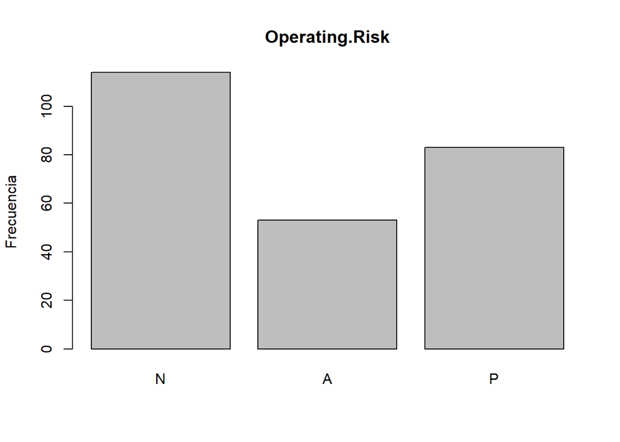

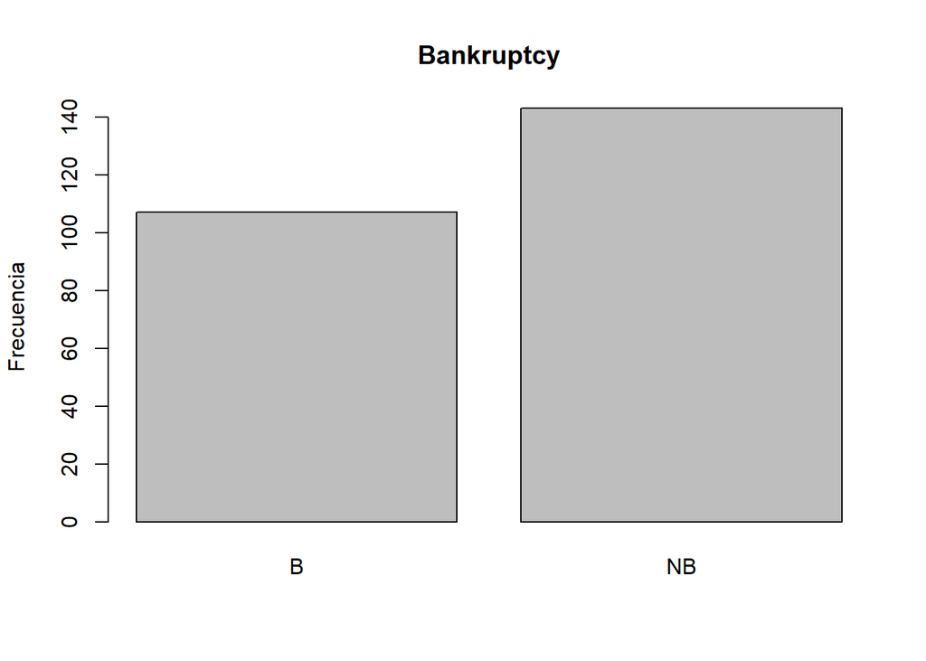

```r
# Gráficos de barras
for (nombre in names(QB_disc)) {
  barplot(table(QB_disc[[nombre]]),
          main = nombre,
          ylab = "Frecuencia")
}
```

Describe, al menos, 2 conclusiones.

### Análisis bivariante de las variables Cualitativas

Obtén la relación entre las variables y la clase (ej. matrices de contingencia). Determina el grado de asociación (ej. $\chi^2$, CramerV, …) entre cada variable y la clase.

*Nota: La función PairApply de la librería DescTools permite calcular estadísticos para todos los pares. La función PlotCorr permite representar los resultados de PairApply.*

```r
#solucion
library(DescTools)
```

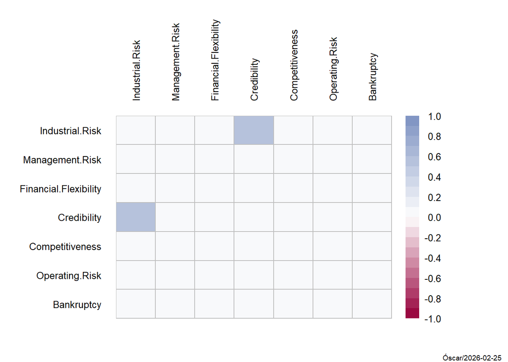

```r
# Hacemos una función que nos ayudará con el cálculo del test chi2, los argumentos (x, y) se espera que sean los nombres de las variables que se quiere analizar su relación o en su defecto serán los índices o posiciones que ocupan como columna dentro del dataframe
Test_chi2 <- function(x,y){
  return(chisq.test(table(x,y))$p.value)
}

Pruebas_chi2 <- PairApply(QB_disc, Test_chi2)
PlotCorr(Pruebas_chi2)
```

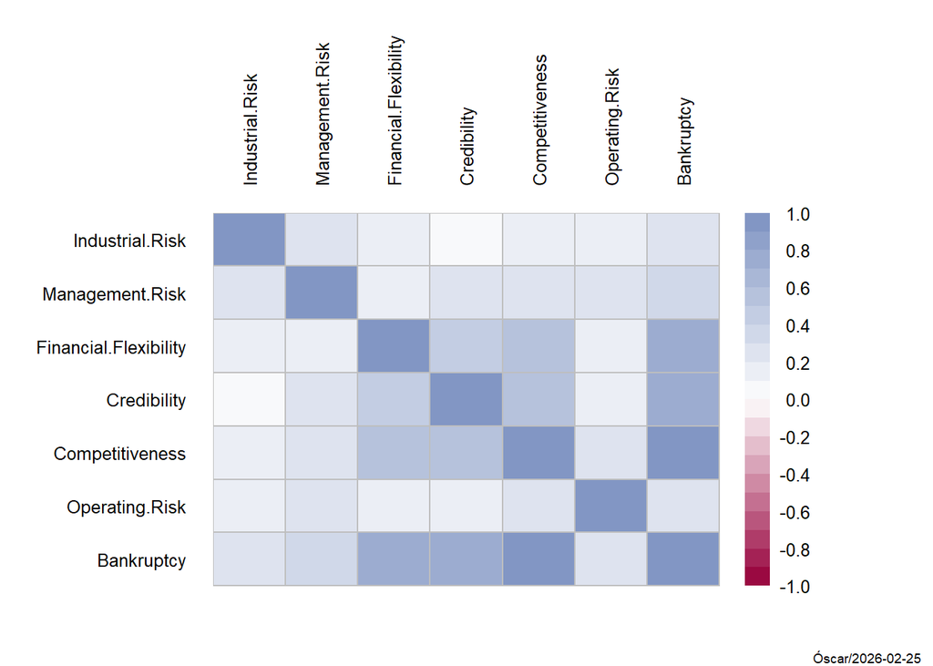

```r
V_de_Cramer <- PairApply(QB_disc, CramerV)
PlotCorr(V_de_Cramer)
```

Contrasta los resultados con los gráficos de Mosaico de los casos más relevantes.

```r
#solucion
library(vcd)
```

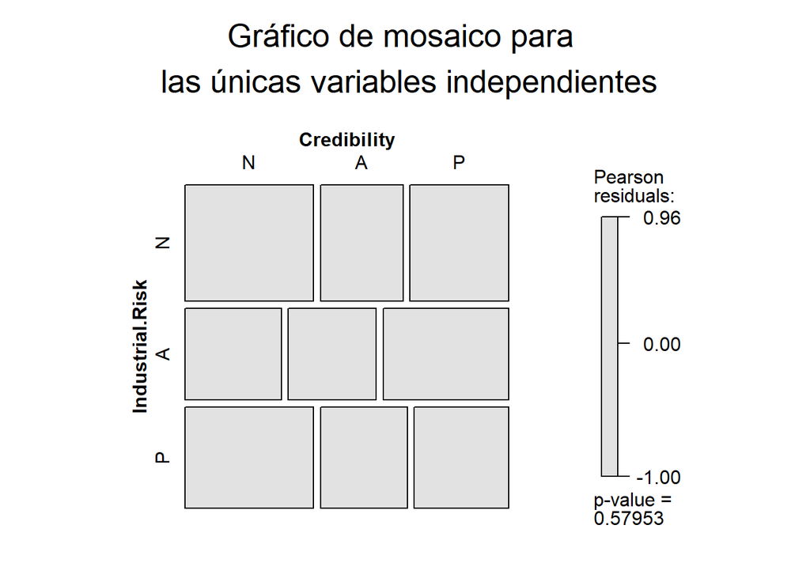

```r
tab1 <- mosaic(formula = ~ Industrial.Risk + Credibility, data=QB_disc, shade=T, main="Gráfico de mosaico para \n las únicas variables independientes")
```

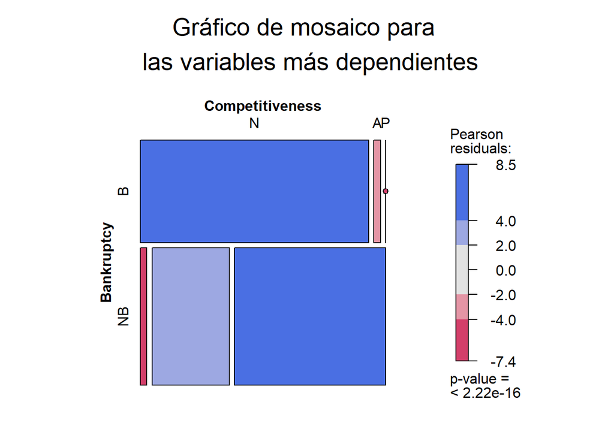

```r
# Ahora los gráficos de mosaico para los pares de variables que tienen una dependencia (V de Cramer) mayor
tab2 <- mosaic(formula = ~ Bankruptcy + Competitiveness, data=QB_disc, shade=T, main="Gráfico de mosaico para \n las variables más dependientes")
```

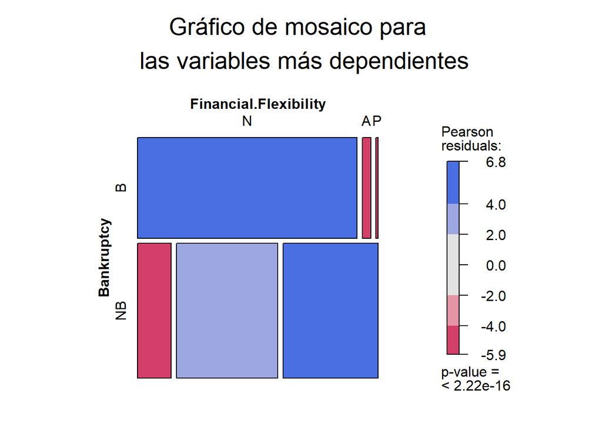

```r
tab3 <- mosaic(formula = ~ Bankruptcy + Financial.Flexibility, data=QB_disc, shade=T, main="Gráfico de mosaico para \n las variables más dependientes")
```

Describe, al menos, 2 conclusiones:

## Reglas de Asociación

Transforma el `data.frame` en *transactions* con el nombre `QBt` y analízalas con `summary`.

```r
#solution
library(arules)

QBt <- as(QB_disc, "transactions")
summary(QBt)
```

```
## transactions as itemMatrix in sparse format with
##  250 rows (elements/itemsets/transactions) and
##  20 columns (items) and a density of 0.35
##
## most frequent items:
##           Bankruptcy=NB Financial.Flexibility=N       Management.Risk=N
##                     143                     123                     121
##        Operating.Risk=N       Competitiveness=N                 (Other)
##                     114                     108                    1141
##
## element (itemset/transaction) length distribution:
## sizes
##   7
## 250
##
##    Min. 1st Qu.  Median    Mean 3rd Qu.    Max.
##       7       7       7       7       7       7
##
## includes extended item information - examples:
##              labels       variables levels
## 1 Industrial.Risk=N Industrial.Risk      N
## 2 Industrial.Risk=A Industrial.Risk      A
## 3 Industrial.Risk=P Industrial.Risk      P
##
## includes extended transaction information - examples:
##   transactionID
## 1             1
## 2             2
## 3             3
```

Obtén las reglas de asociación que tienen, al menos, un `support` del 10% y una `confidence` del 100%. ¿Cuántas reglas se obtienen?

```r
#solution
rules <- apriori(QBt, parameter = list(supp=0.1,
                                    conf=1,
                                    minlen=1,
                                    maxlen=10,
                                    target="rules"),
        control = list(verbose=T))
```

```
## Apriori
##
## Parameter specification:
##  confidence minval smax arem  aval originalSupport maxtime support minlen
##           1    0.1    1 none FALSE            TRUE       5     0.1      1
##  maxlen target  ext
##      10  rules TRUE
##
## Algorithmic control:
##  filter tree heap memopt load sort verbose
##     0.1 TRUE TRUE  FALSE TRUE    2    TRUE
##
## Absolute minimum support count: 25
##
## set item appearances ...[0 item(s)] done [0.00s].
## set transactions ...[20 item(s), 250 transaction(s)] done [0.00s].
## sorting and recoding items ... [20 item(s)] done [0.00s].
## creating transaction tree ... done [0.00s].
## checking subsets of size 1 2 3 4 5 6 done [0.00s].
## writing ... [81 rule(s)] done [0.00s].
## creating S4 object  ... done [0.00s].
```

Muestra las 3 primeras reglas ordenadas por `lift`.

```r
#solution
inspect(head(sort(rules, by = "lift"),n=3))
```

```
##     lhs                     rhs            support confidence coverage     lift count
## [1] {Industrial.Risk=N,
##      Credibility=N}      => {Bankruptcy=B}   0.156          1    0.156 2.336449    39
## [2] {Credibility=N,
##      Competitiveness=N}  => {Bankruptcy=B}   0.336          1    0.336 2.336449    84
## [3] {Management.Risk=N,
##      Competitiveness=N}  => {Bankruptcy=B}   0.280          1    0.280 2.336449    70
```

Obtén las reglas de asociación que tengan como **ANTECEDENTE** `Bankruptcy=B` . Reduce el número de reglas con las condiciones `lift>2 & count>50`. ¿Observas algún patrón/curiosidad en estas reglas?

*Nota: Representar las reglas ayuda en la interpretación.*

```r
#solucion
inspect(subset(rules, subset = lhs %ain% "Bankruptcy=B" & lift>2 & count>50))
```

```
##     lhs                           rhs                 support confidence coverage     lift count
## [1] {Industrial.Risk=N,
##      Bankruptcy=B}             => {Competitiveness=N}   0.220          1    0.220 2.314815    55
## [2] {Operating.Risk=N,
##      Bankruptcy=B}             => {Competitiveness=N}   0.256          1    0.256 2.314815    64
## [3] {Credibility=N,
##      Operating.Risk=N,
##      Bankruptcy=B}             => {Competitiveness=N}   0.216          1    0.216 2.314815    54
## [4] {Financial.Flexibility=N,
##      Operating.Risk=N,
##      Bankruptcy=B}             => {Competitiveness=N}   0.240          1    0.240 2.314815    60
```

Obtén las reglas de asociación en las que **no** aparezca la variable`Bankruptcy` (ni en el antecedente ni en la consecuencia). Representa las reglas. ¿Para qué sirven estas reglas/grafo si no aparece la variable objetivo?

```r
#solution
inspect(subset(rules, subset = !(lhs %pin% "Bankruptcy") & !(rhs %pin% "Bankruptcy")))
```

```
##     lhs                           rhs                 support confidence coverage     lift count
## [1] {Industrial.Risk=N,
##      Credibility=N}            => {Competitiveness=N}   0.156          1    0.156 2.314815    39
## [2] {Industrial.Risk=N,
##      Management.Risk=N,
##      Credibility=N}            => {Competitiveness=N}   0.112          1    0.112 2.314815    28
## [3] {Industrial.Risk=N,
##      Financial.Flexibility=N,
##      Credibility=N}            => {Competitiveness=N}   0.140          1    0.140 2.314815    35
## [4] {Industrial.Risk=N,
##      Management.Risk=N,
##      Financial.Flexibility=N}  => {Competitiveness=N}   0.156          1    0.156 2.314815    39
## [5] {Financial.Flexibility=N,
##      Credibility=N,
##      Operating.Risk=N}         => {Competitiveness=N}   0.200          1    0.200 2.314815    50
## [6] {Management.Risk=N,
##      Financial.Flexibility=N,
##      Operating.Risk=N}         => {Competitiveness=N}   0.140          1    0.140 2.314815    35
## [7] {Management.Risk=N,
##      Financial.Flexibility=N,
##      Credibility=N,
##      Operating.Risk=N}         => {Competitiveness=N}   0.116          1    0.116 2.314815    29
```

Primeramente nos podrían servir para saber que ciertas variables no son independientes unas de otras, aunque ya lo supiésemos por el análisis exploratorio inicial. Otra utilidad sería que estas relaciones nos ayudan a completar el grafo de reglas e implicaciones, sin estas reglas, aunque no incluyan la variable objetivo, las relaciones podrían estar incompletas y es posible que nos faltase información importante sobre los mecanismos mediante los cuales las diferentes variables afectan a la variable objetivo.

## Predicción con reglas de asociación

Desarrolla un modelo de clasificación basado en reglas de asociación para estimar la Bancarrota. Comprueba la bondad del modelo (sensibilidad y especificidad) dividiendo el conjunto de datos en Entrenamiento 80% y Test 20%. Utiliza la función `createDataPartition` y `confusionMatrix` del paquete `caret`.

```r
set.seed(666)
#solucion

#solucion
library(caret)
library(OneR)
# Partición de los datos en entrenamiento y test
train_Index <- createDataPartition(QB_disc$Bankruptcy, times=1, p=0.8, list=F)
QB_train <- QB_disc[train_Index,]
QB_test <- QB_disc[-train_Index,]

modelo_Una_Regla <- OneR(Bankruptcy~., data=QB_train, verbose = F)
summary(modelo_Una_Regla)
```

```
##
## Call:
## OneR.formula(formula = Bankruptcy ~ ., data = QB_train, verbose = F)
##
## Rules:
## If Competitiveness = N then Bankruptcy = B
## If Competitiveness = A then Bankruptcy = NB
## If Competitiveness = P then Bankruptcy = NB
##
## Accuracy:
## 197 of 201 instances classified correctly (98.01%)
##
## Contingency table:
##           Competitiveness
## Bankruptcy    N    A    P Sum
##        B   * 84    2    0  86
##        NB     2 * 38 * 75 115
##        Sum   86   40   75 201
## ---
## Maximum in each column: '*'
##
## Pearson's Chi-squared test:
## X-squared = 185.26, df = 2, p-value < 2.2e-16
```

```r
#prediction_test <- factor(predict(modelo_Una_Regla, newdata=QB_test), levels = c("B", "NB"))
#table(prediction_test, QB_test$Bankruptcy)
```

```r
library(arulesCBA)
modelo_CBA <- CBA(Bankruptcy~.,
                 data=QB_train,
                 verbose = F,
                 parameter = list(supp=0.1,
                                  conf = 1,
                                  minlen = 1,
                                  maxlen = 10))

prediction_CBA_test <- factor(predict(modelo_CBA, QB_test), levels = c("B", "NB"))
prediction_CBA_train <- factor(predict(modelo_CBA, QB_train), levels = c("B", "NB"))

table(prediction_CBA_test, QB_test$Bankruptcy)
```

```
##
## prediction_CBA_test  B NB
##                  B  21  0
##                  NB  0 28
```

```r
table(prediction_CBA_train, QB_train$Bankruptcy)
```

```
##
## prediction_CBA_train   B  NB
##                   B   85   0
##                   NB   1 115
```

Reflexiones sobre el modelo basado en reglas:

¿has utilizado todas las variables en el modelo y por qué?

¿has seleccionado reglas y por qué? ¿en base a qué criterio?